# Electricty Imbalance Cost Distribution Across Months in Turkey

Enes Özeren

6/20/2019

ELECTRICITY MARKET IN TURKEY

Electricity Market is the platform for trading and dealing on prices of electricity for Companies which buy/sell electricity. EPIAS is the operator of Electricity Market in Turkey. This market is mainly formed as a result of heavy cost of electrical energy storage. On the other hand, there are some restrictions about production, electric power transmission, and electricity distribution. Consequently, the Market for Electricity should be performed consistently and carefully.

ELECTRICITY MARKET PRICES

```
In day-ahead market (GÖP in Turkish) the prices for the next day are determined as a result of matching-ups. This price is called PTF in Turkish which stands for market clearing price (MCP). However, most of the time there are differences in production/consumption values between intended and real time. To close the gap between these differences, Balancing Market (DGP) and Intra-day Market (GİP in Turkish) is developed. The prices in Intra-Day Market is called System Marginal Price (SMF in Turkish). For more information about Markets and Prices visit https://www.epias.com.tr/ .
```

COST of IMBALANCES in ELECTRICTY

```
From the difference in MCP and SMP, a cost for companies occurs. The cost is specified according to Positive and Negative Imbalance. Positive Imbalance is result of Electrical Energy Surplus of a company, while Negative Imbalance is result of Electrical Energy Deficit.
A company that has energy surplus can sell electricity to another company in Intra-day Market with MCP. However, a %3 fine is imposed for that trade for that company. This fine can be called as Positive Cost for the company. On the other hand, a company which has energy deficit can buy electricity from another company with SMP. A fine of %3 is imposed on SMP for that company as well. So, the cost from the difference of SMP and MCP and %3 fine can be called as Negative Cost.
In this project, we will analyze the changes of Positive and Negative Costs in Turkey Electricity Market by month.
```

AIM By analyzing the data, our aim is to visualize the cost of the Imbalances in the Market with respect to months.

DATA SOURCE and TIME INTERVAL Data used in this project is imported from EPIAS Transparency Platform. Data imported for the analysis is dated between 01-01-2015 00:00 and 31-05-2019 23:00 to have a better understanding of costs in Turkish currency.

ANALYSIS

Installing libraries that we will need

```r
setwd("/Users/enesozeren/ALGOPOLY/")
library(data.table)
library(lubridate)
library(dplyr)
library(zoo)
```

Importing Data about Electricity Market Prices PTF : Abbreviation of Market Clearing Price in Turkish(“Piyasa Takas Fiyatı”) SMF : Abbreviation of System Marginal Price in Turkish(“Sistem Marjinal Fiyatı”)

```r
#PTF - SMF TOGETHER

PTF_SMF = read.csv("ptf-smf.csv", fileEncoding = "latin1")
```

Rearrange the names of Columns

```r
names(PTF_SMF)[names(PTF_SMF) == "Tarih"] <- "Date"
names(PTF_SMF)[names(PTF_SMF) == "Pozitif.Dengesizlik.Fiyatý..TL.MWh."] <- "Positive_Imbalance_Price(TL/MWh)"
names(PTF_SMF)[names(PTF_SMF) == "Negatif.Dengesizlik.Fiyatý..TL.MWh."] <- "Negative_Imbalance_Price(TL/MWh)"
names(PTF_SMF)[names(PTF_SMF) == "SMF.Yön"] <- "SMF_Direction"
setDT(PTF_SMF)
PTF_SMF[,SMF_Direction:=ifelse(SMF_Direction=="? Enerji Açýðý", "Energy Deficit",
                               ifelse(SMF_Direction=="?Enerji Fazlasý", "Energy Surplus", "Balanced"))]
```

Correction of Data Types

```r
PTF_SMF[, Date:=parse_date_time(Date, "dmy HM")]

PTF_SMF$PTF <- gsub(",", "", as.character(PTF_SMF$PTF), fixed = TRUE)
PTF_SMF$PTF <- as.numeric(PTF_SMF$PTF)
PTF_SMF$PTF <- PTF_SMF$PTF/100
PTF_SMF$SMF <- gsub(",", "", as.character(PTF_SMF$SMF), fixed = TRUE)
PTF_SMF$SMF <- as.numeric(PTF_SMF$SMF)
PTF_SMF$SMF <- PTF_SMF$SMF/100
PTF_SMF$`Positive_Imbalance_Price(TL/MWh)` <- gsub(",", "", as.character(PTF_SMF$`Positive_Imbalance_Price(TL/MWh)`), fixed = TRUE)
PTF_SMF$`Positive_Imbalance_Price(TL/MWh)` <- as.numeric(PTF_SMF$`Positive_Imbalance_Price(TL/MWh)`)
PTF_SMF$`Positive_Imbalance_Price(TL/MWh)` <- PTF_SMF$`Positive_Imbalance_Price(TL/MWh)`/100
PTF_SMF$`Negative_Imbalance_Price(TL/MWh)` <- gsub(",", "", as.character(PTF_SMF$`Negative_Imbalance_Price(TL/MWh)`), fixed = TRUE)
PTF_SMF$`Negative_Imbalance_Price(TL/MWh)` <- as.numeric(PTF_SMF$`Negative_Imbalance_Price(TL/MWh)`)
PTF_SMF$`Negative_Imbalance_Price(TL/MWh)` <- PTF_SMF$`Negative_Imbalance_Price(TL/MWh)`/100
```

Lets check MCP and SMP graphs

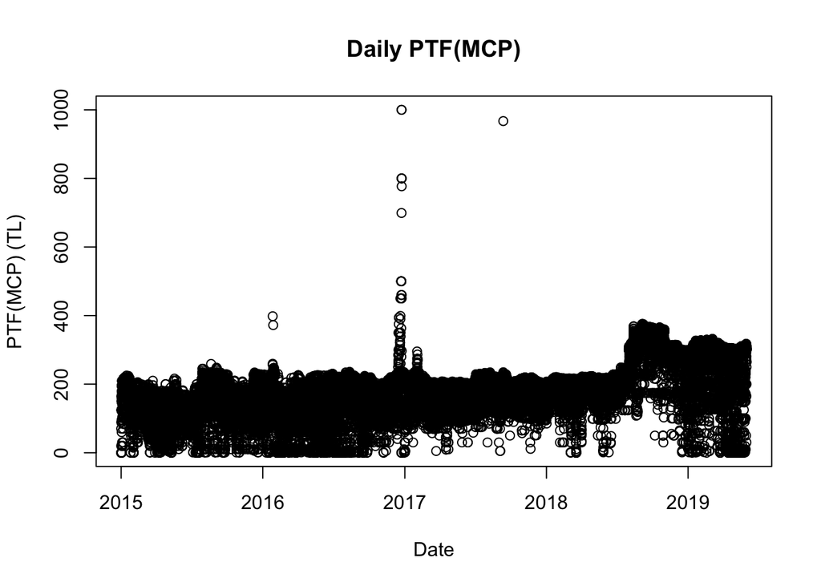

```r
plot(PTF_SMF$Date, PTF_SMF$PTF, xlab = "Date", ylab = "PTF(MCP) (TL)", main = "Daily PTF(MCP)")
```

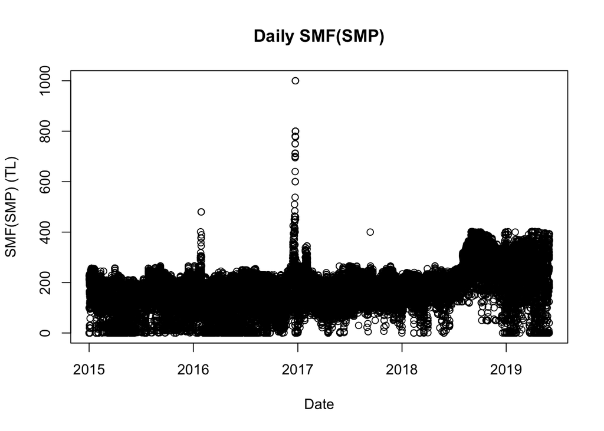

```r
plot(PTF_SMF$Date, PTF_SMF$SMF, xlab = "Date", ylab = "SMF(SMP) (TL)", main = "Daily SMF(SMP)")
```

We can see the outliers in 2016-12-23. The reason for those prices was an energy crisis in Turkey. It was related with natural gas usage and production of electricty.

```r
#Improving data by replacing outliers with median
Interval_2016_December <- PTF_SMF[Date >"2016-12-01 00:00" & Date < "2017-01-01 00:00"]
median(Interval_2016_December$PTF)
```

```
## [1] 213.81
```

```r
median(Interval_2016_December$SMF)
```

```
## [1] 216.05
```

```r
PTF_SMF[, PTF:=ifelse(PTF > 599, median(Interval_2016_December$PTF), PTF)]
PTF_SMF[, SMF:=ifelse(SMF > 599, median(Interval_2016_December$SMF), SMF)]
```

Now we have a better data for analysis.

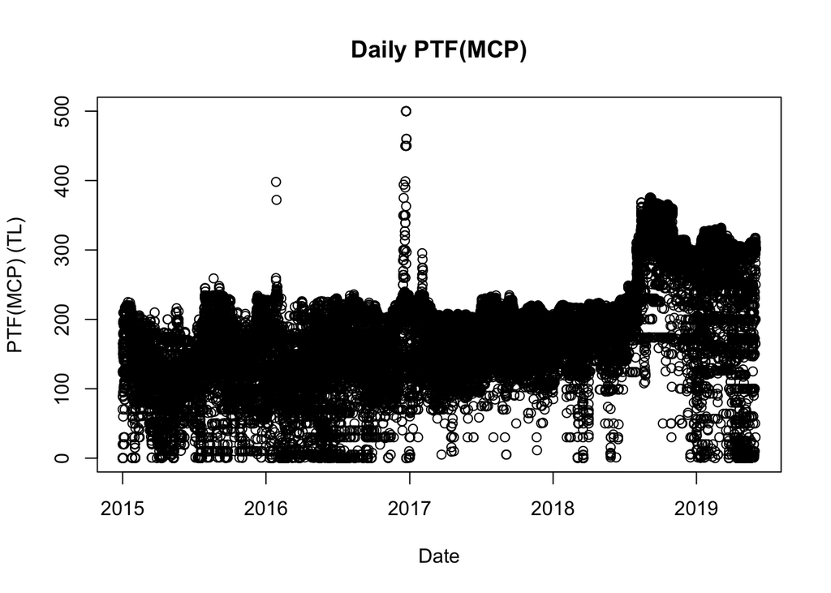

```r
plot(PTF_SMF$Date, PTF_SMF$PTF, xlab = "Date", ylab = "PTF(MCP) (TL)", main = "Daily PTF(MCP)")
```

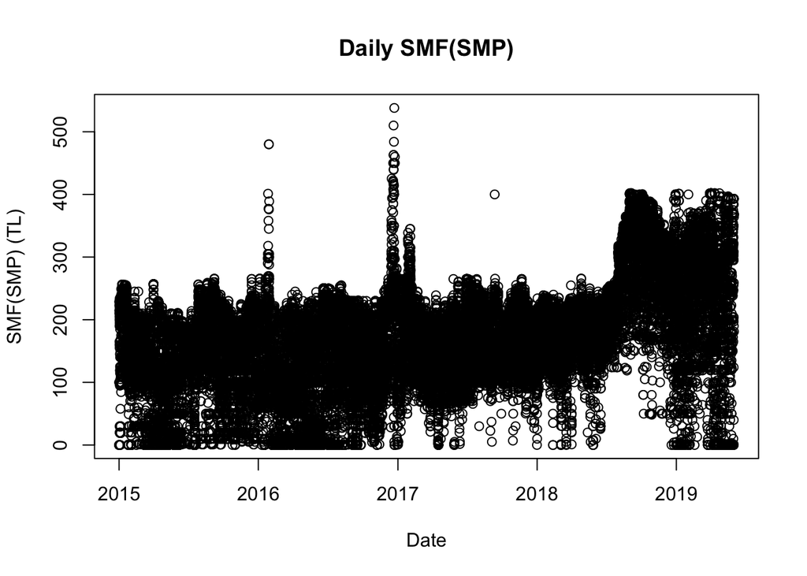

```r
plot(PTF_SMF$Date, PTF_SMF$SMF, xlab = "Date", ylab = "SMF(SMP) (TL)", main = "Daily SMF(SMP)")
```

Calculating Costs in Positive Imbalance(Energy Surplus) and costs in Negative Imbalance(Energy Deficit) cases

```r
PTF_SMF[, Positive_Cost:= PTF-`Positive_Imbalance_Price(TL/MWh)`]
PTF_SMF[, Negative_Cost:=`Negative_Imbalance_Price(TL/MWh)`-PTF]
```

Adding another date type to table, Unix Epoch Time

```r
PTF_SMF$Unix_Epoch_Time <- as.numeric(as.POSIXct(PTF_SMF$Date))
```

Let’s have a look at the Positive Costs and Negative Costs

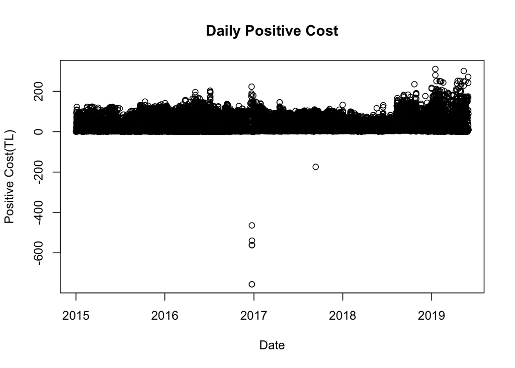

```r
plot(PTF_SMF$Date, PTF_SMF$Positive_Cost, xlab = "Date", ylab = "Positive Cost(TL)", main = "Daily Positive Cost")
```

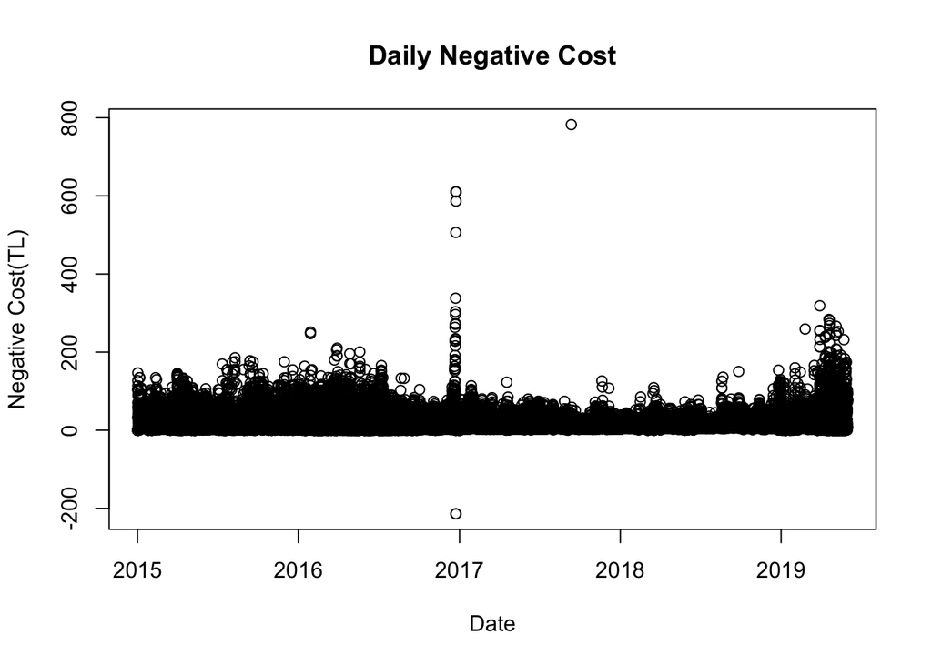

```r
plot(PTF_SMF$Date, PTF_SMF$Negative_Cost, xlab = "Date", ylab = "Negative Cost(TL)", main = "Daily Negative Cost")
```

We can see the outlier values in Positive and Negative Cost because of the same reason above(2016 December energy crisis in Turkey). So let’s replace those values with median values of that month.

```r
#Improving data by replacing outliers with median
Interval_2016_December <- PTF_SMF[Date >"2016-12-01 00:00" & Date < "2017-01-01 00:00"]
median(Interval_2016_December$Positive_Cost)
```

```
## [1] 6.61
```

```r
median(Interval_2016_December$Negative_Cost)
```

```
## [1] 7.05
```

```r
PTF_SMF[, Positive_Cost:=ifelse(Positive_Cost<0, median(Interval_2016_December$Positive_Cost), Positive_Cost)]
PTF_SMF[, Negative_Cost:=ifelse(Negative_Cost<0, median(Interval_2016_December$Negative_Cost), Negative_Cost)]
```

Now let’s check the data again

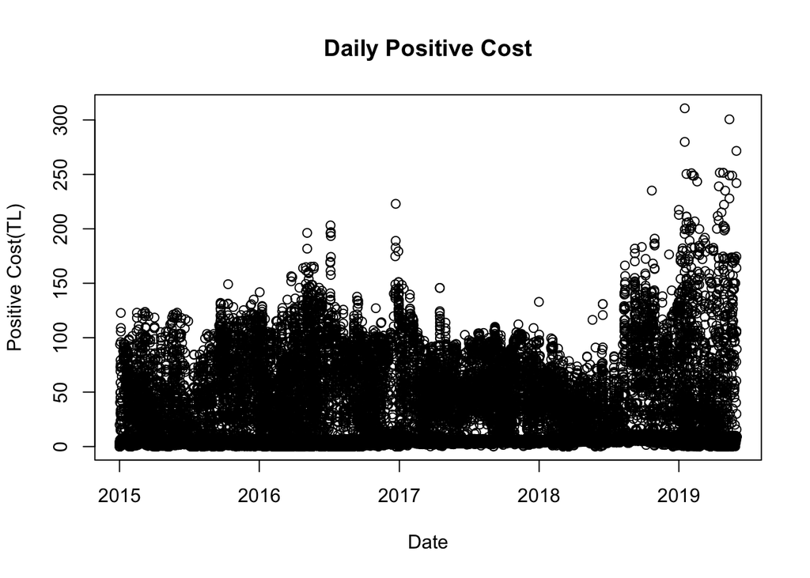

```r
plot(PTF_SMF$Date, PTF_SMF$Positive_Cost, xlab = "Date", ylab = "Positive Cost(TL)", main = "Daily Positive Cost")
```

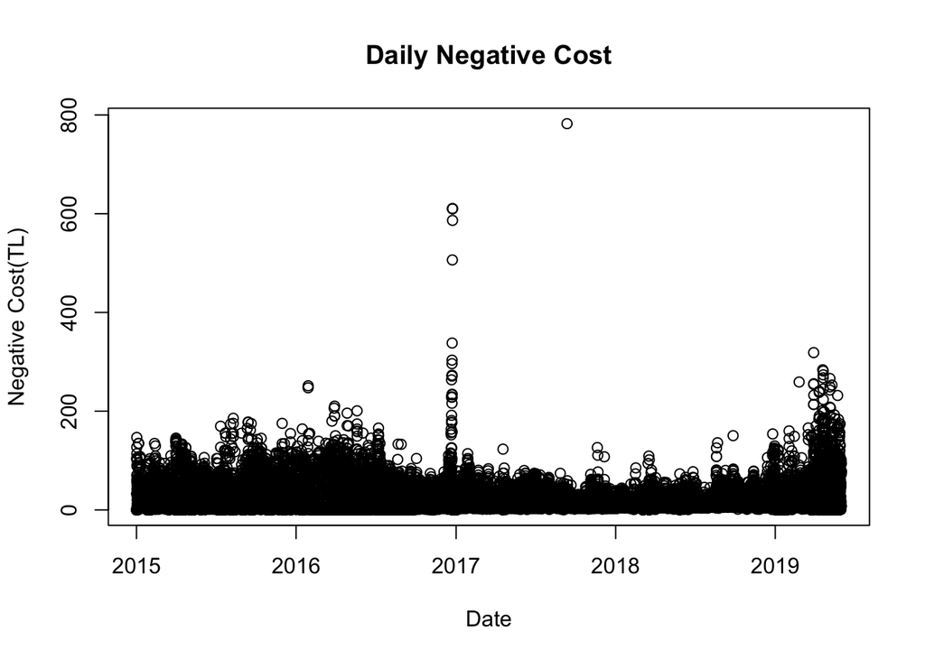

```r
plot(PTF_SMF$Date, PTF_SMF$Negative_Cost, xlab = "Date", ylab = "Negative Cost(TL)", main = "Daily Negative Cost")
```

Importing Data about the Imbalance Amount (Dengesizlik Miktarı in Turkish)

```r
DM_2015 = read.csv("DengesizlikMiktari-01012015-01012016.csv", fileEncoding ="latin1")
DM_2016 = read.csv("DengesizlikMiktari-01012016-01012017.csv", fileEncoding ="latin1")
DM_2017 = read.csv("DengesizlikMiktari-01012017-01012018.csv", fileEncoding ="latin1")
DM_2018 = read.csv("DengesizlikMiktari-01012018-01012019.csv", fileEncoding ="latin1")
DM_2019 = read.csv("DengesizlikMiktari-01012019-31052019.csv", fileEncoding ="latin1")
```

Binding tables

```r
DM = rbind(DM_2015, DM_2016, DM_2017, DM_2018, DM_2019)
```

Rearrange the names of Columns

```r
names(DM)[names(DM)=="Tarih"] <- "date"
names(DM)[names(DM)=="Saat"] <- "hour"
names(DM)[names(DM)=="Pozitif.Dengesizlik.Miktarý..MWh."] <- "P_I_Amount"
names(DM)[names(DM)=="Negatif.Dengesizlik.Miktarý..MWh."] <- "N_I_Amount"
```

Correction of Data Types

```r
DM$date <- as.Date(DM$date, format = "%d / %m / %Y")
DM$P_I_Amount <- gsub(".", "", as.character(DM$P_I_Amount), fixed = TRUE)
DM$P_I_Amount <- gsub(",", "", as.character(DM$P_I_Amount), fixed = TRUE)
DM$P_I_Amount <- as.numeric(DM$P_I_Amount)
DM$P_I_Amount <- DM$P_I_Amount/100
DM$N_I_Amount <- gsub(".", "", as.character(DM$N_I_Amount), fixed = TRUE)
DM$N_I_Amount <- gsub(",", "", as.character(DM$N_I_Amount), fixed = TRUE)
DM$N_I_Amount <- as.numeric(DM$N_I_Amount)
DM$N_I_Amount <- DM$N_I_Amount/100
```

Setting the table as Data Table

```r
setDT(DM)
str(DM)
```

```
## Classes 'data.table' and 'data.frame':   38784 obs. of  4 variables:
##  $ date      : Date, format: "2015-01-01" "2015-01-01" ...
##  $ hour      : Factor w/ 24 levels "00:00","01:00",..: 1 2 3 4 5 6 7 8 9 10 ...
##  $ P_I_Amount: num  1366 1544 2553 3157 3421 ...
##  $ N_I_Amount: num  -1740 -1537 -1512 -1233 -1140 ...
##  - attr(*, ".internal.selfref")=<externalptr>
```

Merging Date and Hour Columns

```r
DM$Date <- paste(DM$date, DM$hour)
DM[, Date:=parse_date_time(DM$Date, "ymd HM")]
DM[, date:=NULL]
DM[, hour:=NULL]
```

Adding another date type to table, Unix Epoch Time

```r
DM$Unix_Epoch_Time <- as.numeric(as.POSIXct(DM$Date))
```

Merging DM and PTF_SMF tables by Unix Epoch Time, then deleting unnecessary columns

```r
DM_PTF_SMF <- merge(DM, PTF_SMF, by="Unix_Epoch_Time")
DM_PTF_SMF[, Date.y:=NULL]
DM_PTF_SMF[, `Positive_Imbalance_Price(TL/MWh)`:=NULL]
DM_PTF_SMF[, `Negative_Imbalance_Price(TL/MWh)`:=NULL]
DM_PTF_SMF[, PTF:=NULL]
DM_PTF_SMF[, SMF:=NULL]
DM_PTF_SMF[, Cost:= NULL]
DM_PTF_SMF[, SMF_Direction:= NULL]
```

Calculating Daily Total Cost

```r
DM_PTF_SMF[, Total_Cost:= P_I_Amount*Positive_Cost + abs(N_I_Amount)*Negative_Cost]
```

Extracting Month and Year of every row into a new column Then seperating Month and Year values into different columns

```r
DM_PTF_SMF[, Month_Year:=format(as.Date(Date.x, format = "%Y-%m-%d %H:%M:%S"),"%m-%Y")]

#  Get months
DM_PTF_SMF$Month <- months(DM_PTF_SMF$Date.x)

#  Get years
DM_PTF_SMF$Year <- format(DM_PTF_SMF$Date.x,format="%y")

DM_PTF_SMF
```

```
##        Unix_Epoch_Time P_I_Amount N_I_Amount              Date.x
##     1:      1420070400    1366.16   -1740.42 2015-01-01 00:00:00
##     2:      1420074000    1544.37   -1536.89 2015-01-01 01:00:00
##     3:      1420077600    2553.16   -1511.55 2015-01-01 02:00:00
##     4:      1420081200    3156.59   -1233.43 2015-01-01 03:00:00
##     5:      1420084800    3421.02   -1139.80 2015-01-01 04:00:00
##    ---
## 38784:      1559329200    1035.89   -2191.23 2019-05-31 19:00:00
## 38785:      1559332800    1148.84   -1822.98 2019-05-31 20:00:00
## 38786:      1559336400    1079.40   -1546.01 2019-05-31 21:00:00
## 38787:      1559340000    1082.81   -1895.63 2019-05-31 22:00:00
## 38788:      1559343600    1944.28   -1268.59 2019-05-31 23:00:00
##        Positive_Cost Negative_Cost Total_Cost Month_Year   Month Year
##     1:          2.11         32.77   59916.16    01-2015 January   15
##     2:         20.02          0.60   31840.42    01-2015 January   15
##     3:          0.00          0.00       0.00    01-2015 January   15
##     4:          0.00          0.00       0.00    01-2015 January   15
##     5:          0.00          0.00       0.00    01-2015 January   15
##    ---
## 38784:          9.00         79.04  182517.83    05-2019     May   19
## 38785:          9.03         77.99  152548.24    05-2019     May   19
## 38786:          9.08         72.34  121639.32    05-2019     May   19
## 38787:          9.09         76.01  153929.58    05-2019     May   19
## 38788:         89.42          7.95  183942.81    05-2019     May   19
```

Getting Monthly Average of Total Cost

```r
Monthly_Average_of_Total_Cost <-  aggregate(Total_Cost~ Month + Year, DM_PTF_SMF, mean)

Monthly_Average_of_Total_Cost
```

```
##        Month Year Total_Cost
## 1      April   15   95413.09
## 2     August   15   53917.85
## 3   December   15   65055.99
## 4   February   15   63362.95
## 5    January   15   81938.14
## 6       July   15   56863.40
## 7       June   15   59831.54
## 8      March   15   60469.72
## 9        May   15   75418.79
## 10  November   15   61760.43
## 11   October   15   72435.06
## 12 September   15   92580.96
## 13     April   16   96160.43
## 14    August   16   59572.86
```

[output cut: 39 more lines]

Creating a new Date column to have a different type of date syntax

```r
Monthly_Average_of_Total_Cost$Month <- match(Monthly_Average_of_Total_Cost$Month, month.name)
Monthly_Average_of_Total_Cost$Date <-
  as.yearmon(paste(Monthly_Average_of_Total_Cost$Month, Monthly_Average_of_Total_Cost$Year), "%m %y")
```

Setting table as Data Table and ordering rows by date

```r
setDT(Monthly_Average_of_Total_Cost)
Monthly_Average_of_Total_Cost <-
  Monthly_Average_of_Total_Cost[order(as.Date(Monthly_Average_of_Total_Cost$Date, format = "%b %Y"))]

Monthly_Average_of_Total_Cost
```

```
##     Month Year Total_Cost     Date
##  1:     1   15   81938.14 Jan 2015
##  2:     2   15   63362.95 Feb 2015
##  3:     3   15   60469.72 Mar 2015
##  4:     4   15   95413.09 Apr 2015
##  5:     5   15   75418.79 May 2015
##  6:     6   15   59831.54 Jun 2015
##  7:     7   15   56863.40 Jul 2015
##  8:     8   15   53917.85 Aug 2015
##  9:     9   15   92580.96 Sep 2015
## 10:    10   15   72435.06 Oct 2015
## 11:    11   15   61760.43 Nov 2015
## 12:    12   15   65055.99 Dec 2015
## 13:     1   16   94012.79 Jan 2016
## 14:     2   16   52511.75 Feb 2016
```

[output cut: 40 more lines]

Now let’s see Monthly Average Total Costs

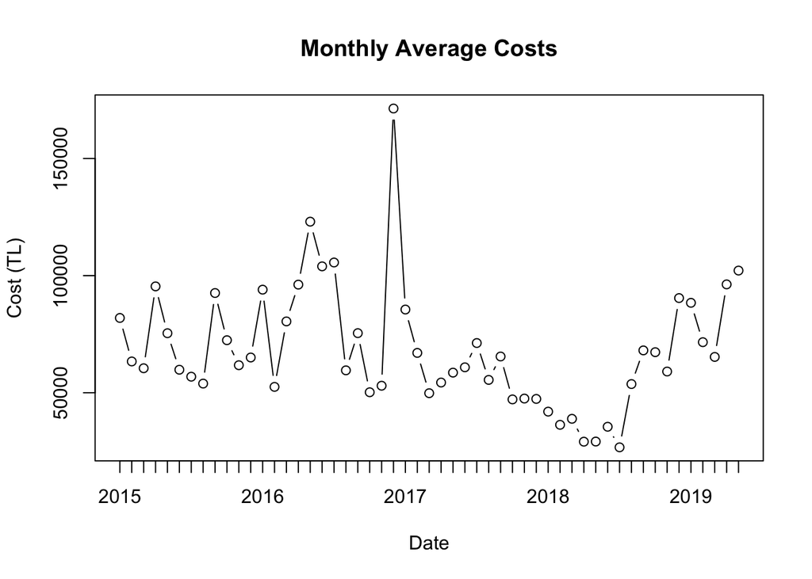

```r
plot(Monthly_Average_of_Total_Cost$Date, Monthly_Average_of_Total_Cost$Total_Cost, xlab = "Date",
     ylab = "Cost (TL)", main = "Monthly Average Costs", type = "b")
```

To have a clear vision, let’s calculate the mean of Total Cost for months.

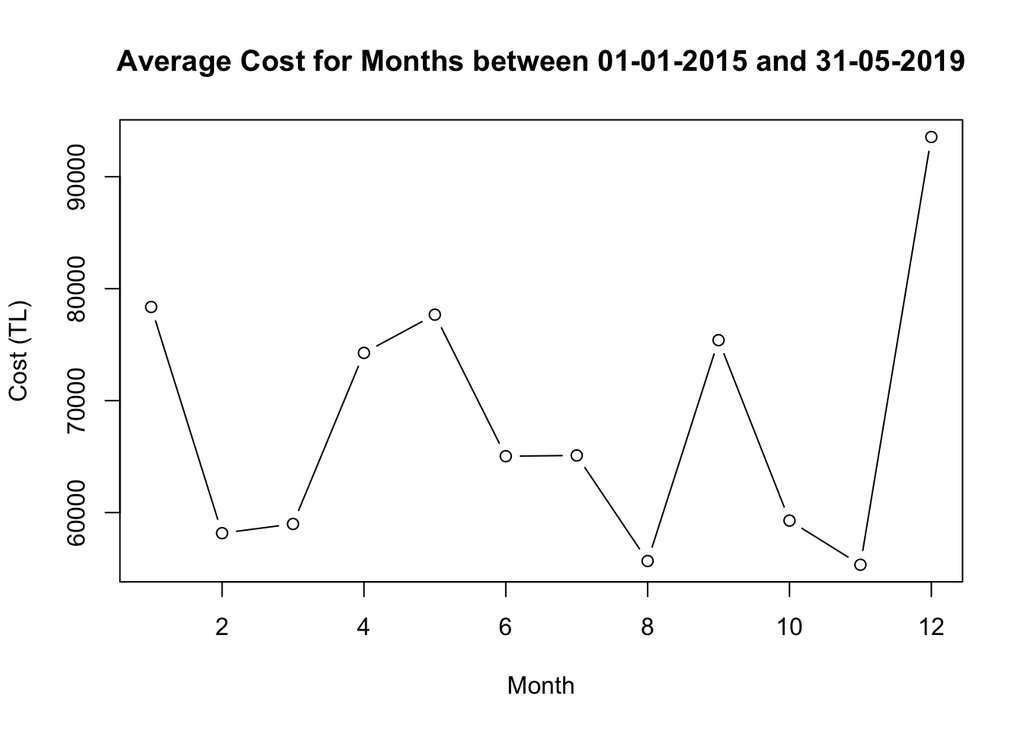

```r
Temp <- copy(Monthly_Average_of_Total_Cost)
General_Average <- aggregate(Total_Cost~  Month, Temp, mean)
names(General_Average)[names(General_Average)=="Total_Cost"] <- "Average_Daily_Cost"

plot(General_Average$Month, General_Average$Average_Daily_Cost, type = "b",
     xlab = "Month", ylab = "Cost (TL)", main = "Average Cost for Months between 01-01-2015 and 31-05-2019")
```

Result from our final graph:

Exact Values of daily average of Electricity Imbalance Costs for Each Month:

```r
General_Average$Month <- month.name[General_Average$Month]
General_Average
```

```
##        Month Average_Daily_Cost
## 1    January           78363.95
## 2   February           58160.52
## 3      March           58985.56
## 4      April           74263.19
## 5        May           77677.88
## 6       June           65036.52
## 7       July           65102.37
## 8     August           55674.71
## 9  September           75401.19
## 10   October           59285.32
## 11  November           55339.26
## 12  December           93547.65
```

Statistical Values for average costs for months:

```r
summary(General_Average$Average_Daily_Cost)
```

```
##    Min. 1st Qu.  Median    Mean 3rd Qu.    Max.
##   55339   58779   65069   68070   75970   93548
```

CONCLUSION